# Marketing Campaign

- AI - Computer Assignment 4
- Machine Learning Task
- **Mohammad Mahdi Salmani**

## Check the data set

```python
import pandas as pd
import numpy as np
import seaborn as sns
import matplotlib.pyplot as plt
```

```python
df = pd.read_csv('marketing_campaign.csv')
```

### Q1: dataset info

```python
df.info()
```

```
<class 'pandas.core.frame.DataFrame'>
RangeIndex: 2240 entries, 0 to 2239
Data columns (total 20 columns):
 #   Column             Non-Null Count  Dtype
---  ------             --------------  -----
 0   Unnamed: 0         2240 non-null   int64
 1   ID                 2240 non-null   int64
 2   Year_Birth         2240 non-null   int64
 3   Education          2240 non-null   object
 4   Marital_Status     2240 non-null   object
 5   Income             2017 non-null   float64
 6   Kidhome            2240 non-null   int64
 7   Teenhome           2240 non-null   int64
 8   Dt_Customer        2240 non-null   object
 9   Recency            2240 non-null   int64
 10  MntCoffee          2035 non-null   float64
 11  MntFruits          2240 non-null   int64
 12  MntMeatProducts    2240 non-null   int64
 13  MntFishProducts    2240 non-null   int64
 14  MntSweetProducts   2240 non-null   int64
 15  MntGoldProds       2227 non-null   float64
 16  NumWebVisitsMonth  2040 non-null   float64
 17  Complain           2240 non-null   int64
 18  NumPurchases       2240 non-null   int64
 19  UsedCampaignOffer  2240 non-null   int64
dtypes: float64(4), int64(13), object(3)
memory usage: 350.1+ KB
```

```python
df.drop(labels=['Unnamed: 0'],axis=1,inplace=True)
df.describe()
```

|  | ID | Year_Birth | Income | Kidhome | Teenhome | Recency | MntCoffee | MntFruits | MntMeatProducts | MntFishProducts | MntSweetProducts | MntGoldProds | NumWebVisitsMonth | Complain | NumPurchases | UsedCampaignOffer |
| --- | --- | --- | --- | --- | --- | --- | --- | --- | --- | --- | --- | --- | --- | --- | --- | --- |
| count | 2240.000000 | 2240.000000 | 2017.000000 | 2240.000000 | 2240.000000 | 2240.000000 | 2035.000000 | 2240.000000 | 2240.000000 | 2240.000000 | 2240.000000 | 2227.000000 | 2040.000000 | 2240.000000 | 2240.000000 | 2240.000000 |
| mean | 5592.159821 | 1968.805804 | 52297.080317 | 0.437946 | 0.506250 | 49.109375 | 304.239312 | 26.302232 | 166.950000 | 37.525446 | 27.062946 | 43.847777 | 5.326961 | 0.009375 | 14.862054 | 0.271875 |
| std | 3246.662198 | 11.984069 | 25543.108215 | 0.563666 | 0.544538 | 28.962453 | 337.515534 | 39.773434 | 225.715373 | 54.628979 | 41.280498 | 51.897098 | 2.439349 | 0.096391 | 7.677173 | 0.445025 |
| min | 0.000000 | 1893.000000 | 2447.000000 | -5.000000 | 0.000000 | 0.000000 | 0.000000 | 0.000000 | 0.000000 | 0.000000 | 0.000000 | 0.000000 | 0.000000 | 0.000000 | 0.000000 | 0.000000 |
| 25% | 2828.250000 | 1959.000000 | 35340.000000 | 0.000000 | 0.000000 | 24.000000 | 23.000000 | 1.000000 | 16.000000 | 3.000000 | 1.000000 | 9.000000 | 3.000000 | 0.000000 | 8.000000 | 0.000000 |
| 50% | 5458.500000 | 1970.000000 | 51369.000000 | 0.000000 | 0.000000 | 49.000000 | 177.000000 | 8.000000 | 67.000000 | 12.000000 | 8.000000 | 24.000000 | 6.000000 | 0.000000 | 15.000000 | 0.000000 |
| 75% | 8427.750000 | 1977.000000 | 68316.000000 | 1.000000 | 1.000000 | 74.000000 | 505.000000 | 33.000000 | 232.000000 | 50.000000 | 33.000000 | 56.000000 | 7.000000 | 0.000000 | 21.000000 | 1.000000 |
| max | 11191.000000 | 1996.000000 | 666666.000000 | 2.000000 | 2.000000 | 99.000000 | 1493.000000 | 199.000000 | 1725.000000 | 259.000000 | 263.000000 | 362.000000 | 20.000000 | 1.000000 | 44.000000 | 1.000000 |

```python
df.head(10)
```

|  | ID | Year_Birth | Education | Marital_Status | Income | Kidhome | Teenhome | Dt_Customer | Recency | MntCoffee | MntFruits | MntMeatProducts | MntFishProducts | MntSweetProducts | MntGoldProds | NumWebVisitsMonth | Complain | NumPurchases | UsedCampaignOffer |
| --- | --- | --- | --- | --- | --- | --- | --- | --- | --- | --- | --- | --- | --- | --- | --- | --- | --- | --- | --- |
| 0 | 5524 | 1957 | Graduation | Single | 58138.0 | 0 | 0 | 04-09-2012 | 58 | 635.0 | 88 | 546 | 172 | 88 | 88.0 | NaN | 0 | 25 | 1 |
| 1 | 2174 | 1954 | Graduation | Single | 46344.0 | 1 | 1 | 08-03-2014 | 38 | NaN | 1 | 6 | 2 | 1 | 6.0 | 5.0 | 0 | 6 | 0 |
| 2 | 4141 | 1965 | Graduation | Together | 71613.0 | 0 | 0 | 21-08-2013 | 26 | NaN | 49 | 127 | 111 | 21 | 42.0 | NaN | 0 | 21 | 0 |
| 3 | 6182 | 1984 | Graduation | Together | 26646.0 | 1 | 0 | 10-02-2014 | 26 | 11.0 | 4 | 20 | 10 | 3 | 5.0 | 6.0 | 0 | 8 | 0 |
| 4 | 5324 | 1981 | PhD | Married | 58293.0 | 1 | 0 | 19-01-2014 | 94 | 173.0 | 43 | 118 | 46 | 27 | 15.0 | 5.0 | 0 | 19 | 0 |
| 5 | 7446 | 1967 | Master | Together | NaN | 0 | 1 | 09-09-2013 | 16 | 520.0 | 42 | 98 | 0 | 42 | 14.0 | NaN | 0 | 22 | 0 |
| 6 | 965 | 1971 | Graduation | Divorced | 55635.0 | 0 | 1 | 13-11-2012 | 34 | 235.0 | 65 | 164 | 50 | 49 | 27.0 | 6.0 | 0 | 21 | 0 |
| 7 | 6177 | 1985 | PhD | Married | 33454.0 | 1 | 0 | 08-05-2013 | 32 | 76.0 | 10 | 56 | 3 | 1 | 23.0 | 8.0 | 0 | 10 | 0 |
| 8 | 4855 | 1974 | PhD | Together | 30351.0 | 1 | 0 | 06-06-2013 | 19 | 14.0 | 0 | 24 | 3 | 3 | 2.0 | 9.0 | 0 | 6 | 1 |
| 9 | 5899 | 1950 | PhD | Together | 5648.0 | 1 | 1 | 13-03-2014 | 68 | 28.0 | 0 | 6 | 1 | 1 | 13.0 | 20.0 | 0 | 2 | 1 |

### Q2: missing values

```python
df.isnull().sum()
```

```
ID                     0
Year_Birth             0
Education              0
Marital_Status         0
Income               223
Kidhome                0
Teenhome               0
Dt_Customer            0
Recency                0
MntCoffee            205
MntFruits              0
MntMeatProducts        0
MntFishProducts        0
MntSweetProducts       0
MntGoldProds          13
NumWebVisitsMonth    200
Complain               0
NumPurchases           0
UsedCampaignOffer      0
dtype: int64
```

```python
null_values = {df.columns[i]:num/len(df) for i, num in enumerate(df.isnull().sum()) if num>0}
for name, percent in null_values.items():
    print(f'{name:20s} % {100*percent:.1f}')
```

```
Income               % 10.0
MntCoffee            % 9.2
MntGoldProds         % 0.6
NumWebVisitsMonth    % 8.9
```

### Q3: correlation matrix

[figure not shown]

```python
# Calculate the correlation matrix
corr_matrix = df.select_dtypes(include=['number']).corr()

# Create a heatmap
plt.figure(figsize=(12, 10))
sns.heatmap(corr_matrix, annot=True, cmap='coolwarm', fmt='.2f', linewidths=.5)
plt.title('Correlation Matrix')
plt.show()
```

```python
# Calculate the correlation matrix
correlation_with_target = df.select_dtypes(include=['number']).corr()['NumPurchases'].abs().sort_values(ascending=False)
top_correlated_features = correlation_with_target[1:4]
# Print the correlation values
print(top_correlated_features)
```

```
MntCoffee          0.715164
Income             0.562603
MntMeatProducts    0.554229
Name: NumPurchases, dtype: float64
```

### Q4

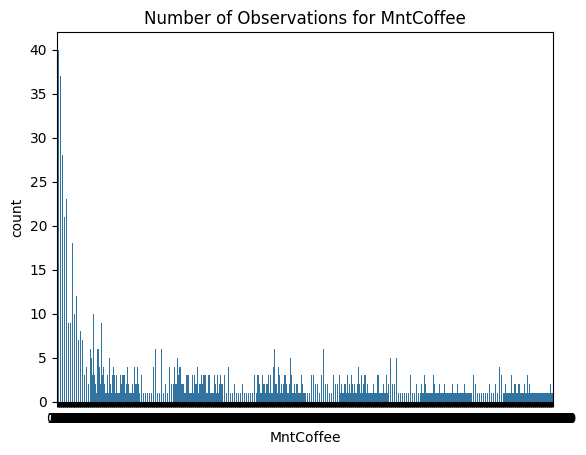

```python
sns.countplot(x=df['MntCoffee'], data=df)
plt.title(f'Number of Observations for MntCoffee')
plt.show()
```

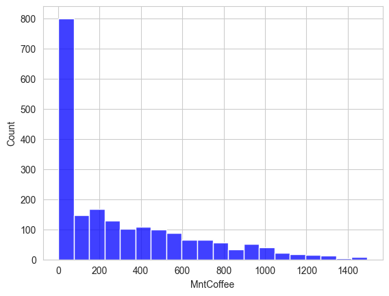

```python
sns.set_style("whitegrid")
sns.histplot(df['MntCoffee'],color='blue')
plt.show()
```

```python
top_correlated_features.keys()
```

```
Index(['MntCoffee', 'Income', 'MntMeatProducts'], dtype='object')
```

### Q5: scatter plot and hexbin plot

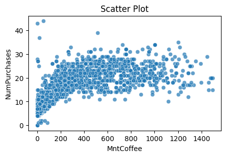

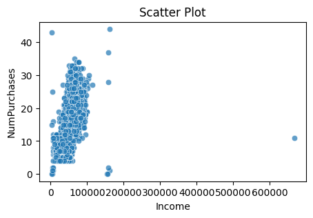

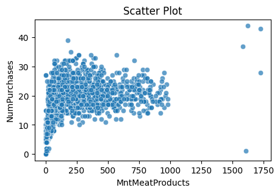

```python
for feature in top_correlated_features.keys():
    plt.figure(figsize=(5, 3))
    sns.scatterplot(x=feature, y='NumPurchases', data=df, alpha=0.7)
    plt.title('Scatter Plot')
    plt.xlabel(feature)
    plt.ylabel('NumPurchases')
    plt.show()
```

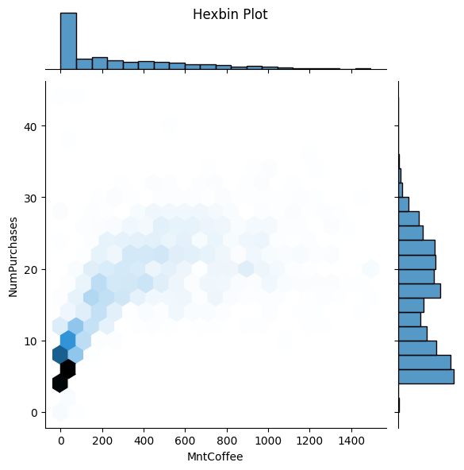

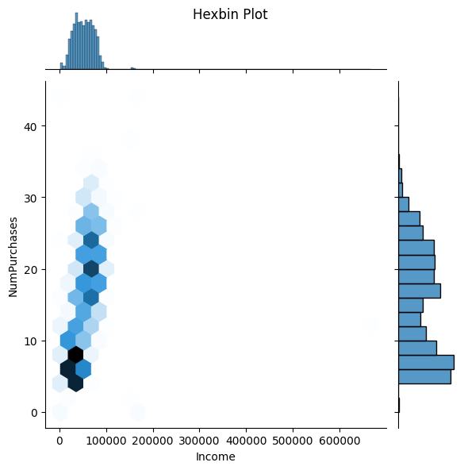

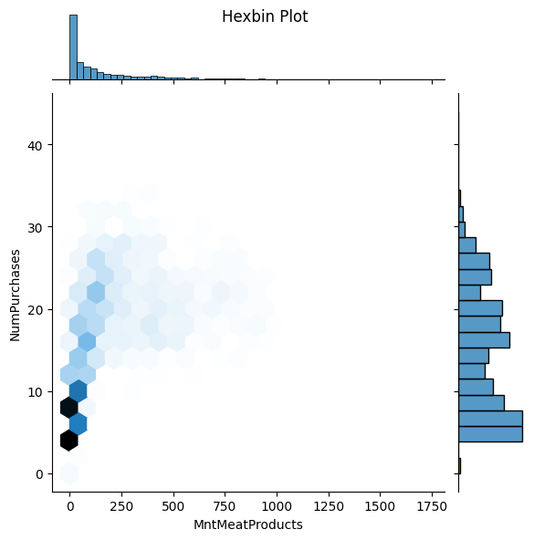

```python
for feature in top_correlated_features.keys():
    # plt.figure()
    sns.jointplot(x=feature, y='NumPurchases', data=df, kind='hex', gridsize=20)
    plt.suptitle('Hexbin Plot')
plt.show()
```

### Q6

```python
df['NumPurchases'].unique()
```

```
array([25,  6, 21,  8, 19, 22, 10,  2,  4, 16, 15,  5, 26,  9, 13, 12, 43,
       17, 20, 14, 27, 11, 18, 28,  7, 24, 29, 23, 32, 30, 37, 31, 33, 35,
       39,  1, 34,  0, 44], dtype=int64)
```

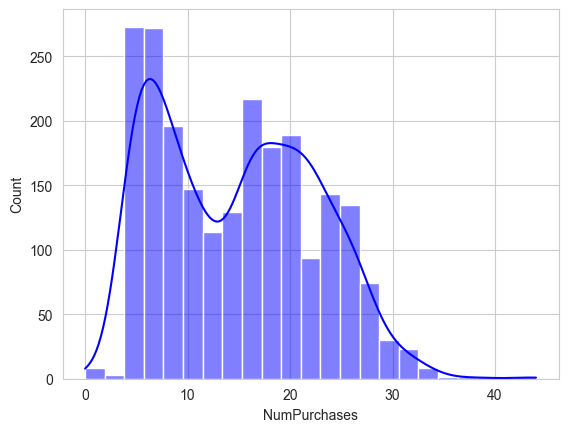

```python
sns.set_style("whitegrid")
sns.histplot(df['NumPurchases'],kde=True,color='blue')
plt.show()
```

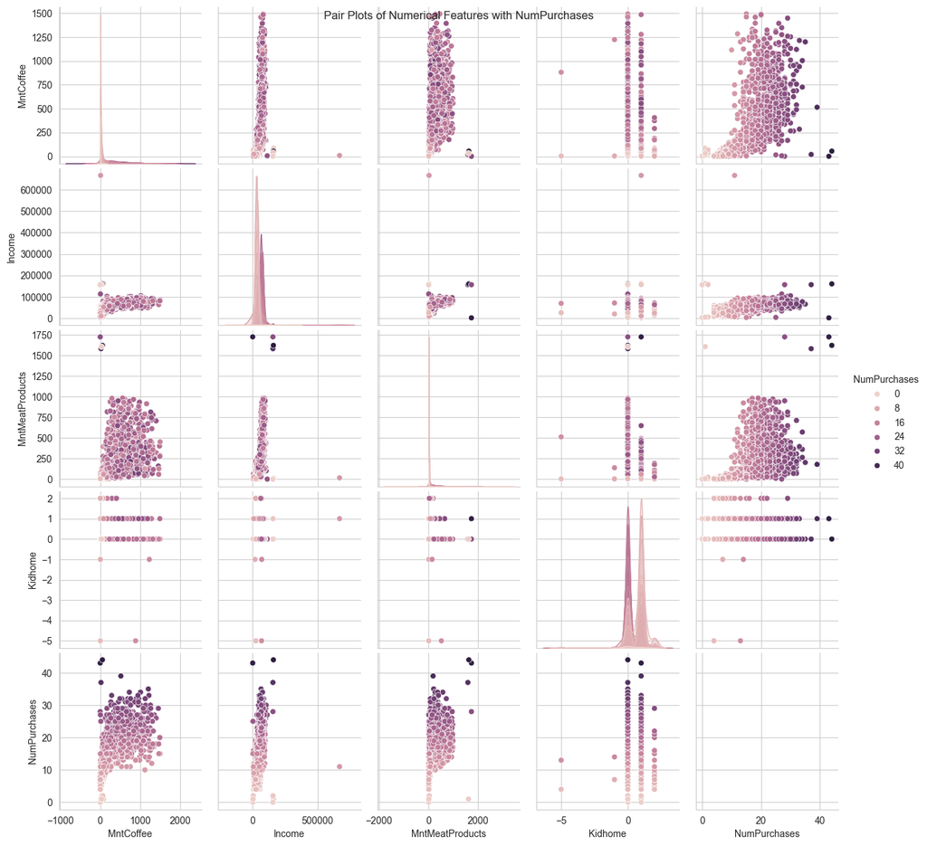

```python
sns.pairplot(df, vars=['MntCoffee', 'Income', 'MntMeatProducts', 'Kidhome', 'NumPurchases'], hue='NumPurchases')
plt.suptitle('Pair Plots of Numerical Features with NumPurchases')
plt.show()
```

## Preprocessing dataset

### Q8: Handle missing values

```python
# Separate numeric and categorical columns
numeric_columns = df.select_dtypes(include=['number']).columns
categoric_columns = df.select_dtypes(include=['object']).columns

# Fill missing values in numeric columns with the mean
df[numeric_columns] = df[numeric_columns].fillna(df[numeric_columns].mean())

# Fill missing values in categorical columns with the mode
df[categoric_columns] = df[categoric_columns].apply(lambda x: x.fillna(x.mode()[0]))
```

### Q9: normalizing, standardizing numerical features

```python
from sklearn.preprocessing import StandardScaler

scaler = StandardScaler()
df_standardized = pd.DataFrame(scaler.fit_transform(df[numeric_columns]), columns=df[numeric_columns].columns)
df_standardized = df_standardized.join(df[categoric_columns])
```

```python
df_standardized.describe()
```

|  | ID | Year_Birth | Income | Kidhome | Teenhome | Recency | MntCoffee | MntFruits | MntMeatProducts | MntFishProducts | MntSweetProducts | MntGoldProds | NumWebVisitsMonth | Complain | NumPurchases | UsedCampaignOffer |
| --- | --- | --- | --- | --- | --- | --- | --- | --- | --- | --- | --- | --- | --- | --- | --- | --- |
| count | 2.240000e+03 | 2.240000e+03 | 2.240000e+03 | 2.240000e+03 | 2.240000e+03 | 2.240000e+03 | 2.240000e+03 | 2.240000e+03 | 2.240000e+03 | 2.240000e+03 | 2.240000e+03 | 2.240000e+03 | 2.240000e+03 | 2.240000e+03 | 2.240000e+03 | 2.240000e+03 |
| mean | 2.220446e-17 | -8.133970e-15 | -7.930164e-17 | 5.392512e-17 | -3.172066e-18 | -3.172066e-18 | -6.344132e-18 | -2.379049e-17 | 4.123686e-17 | 1.506731e-17 | -1.506731e-17 | 1.427430e-16 | -8.247371e-17 | -3.053113e-17 | -1.110223e-17 | 3.806479e-17 |
| std | 1.000223e+00 | 1.000223e+00 | 1.000223e+00 | 1.000223e+00 | 1.000223e+00 | 1.000223e+00 | 1.000223e+00 | 1.000223e+00 | 1.000223e+00 | 1.000223e+00 | 1.000223e+00 | 1.000223e+00 | 1.000223e+00 | 1.000223e+00 | 1.000223e+00 | 1.000223e+00 |
| min | -1.722818e+00 | -6.326960e+00 | -2.057173e+00 | -9.649610e+00 | -9.298944e-01 | -1.696001e+00 | -9.459542e-01 | -6.614492e-01 | -7.398135e-01 | -6.870680e-01 | -6.557331e-01 | -8.475512e-01 | -2.288869e+00 | -9.728167e-02 | -1.936308e+00 | -6.110569e-01 |
| 25% | -8.514982e-01 | -8.184192e-01 | -6.343421e-01 | -7.771339e-01 | -9.298944e-01 | -8.671566e-01 | -8.620046e-01 | -6.363012e-01 | -6.689119e-01 | -6.321399e-01 | -6.315032e-01 | -6.735866e-01 | -5.701636e-01 | -9.728167e-02 | -8.940252e-01 | -6.110569e-01 |
| 50% | -4.117757e-02 | 9.967091e-02 | 0.000000e+00 | -7.771339e-01 | -9.298944e-01 | -3.777284e-03 | -2.417105e-01 | -4.602650e-01 | -4.429132e-01 | -4.673554e-01 | -4.618937e-01 | -3.643162e-01 | 0.000000e+00 | -9.728167e-02 | 1.797240e-02 | -6.110569e-01 |
| 75% | 8.735813e-01 | 6.839101e-01 | 5.814825e-01 | 9.973614e-01 | 9.069340e-01 | 8.596020e-01 | 4.811887e-01 | 1.684356e-01 | 2.882592e-01 | 2.284015e-01 | 1.438543e-01 | 2.348952e-01 | 7.188653e-01 | -9.728167e-02 | 7.996846e-01 | 1.636509e+00 |
| max | 1.724876e+00 | 2.269702e+00 | 2.535329e+01 | 2.771857e+00 | 2.743762e+00 | 1.722981e+00 | 3.696147e+00 | 4.343008e+00 | 6.904261e+00 | 4.055064e+00 | 5.716737e+00 | 6.149691e+00 | 6.304657e+00 | 1.027943e+01 | 3.796248e+00 | 1.636509e+00 |

```python
from sklearn.preprocessing import MinMaxScaler

scaler = MinMaxScaler(feature_range=(0,1))
df_normalized = pd.DataFrame(scaler.fit_transform(df[numeric_columns]), columns=df[numeric_columns].columns)
df_normalized = df_normalized.join(df[categoric_columns])
```

```python
df_normalized.describe()
```

|  | ID | Year_Birth | Income | Kidhome | Teenhome | Recency | MntCoffee | MntFruits | MntMeatProducts | MntFishProducts | MntSweetProducts | MntGoldProds | NumWebVisitsMonth | Complain | NumPurchases | UsedCampaignOffer |
| --- | --- | --- | --- | --- | --- | --- | --- | --- | --- | --- | --- | --- | --- | --- | --- | --- |
| count | 2240.000000 | 2240.000000 | 2240.000000 | 2240.000000 | 2240.000000 | 2240.000000 | 2240.000000 | 2240.000000 | 2240.000000 | 2240.000000 | 2240.000000 | 2240.000000 | 2240.000000 | 2240.000000 | 2240.000000 | 2240.000000 |
| mean | 0.499702 | 0.735979 | 0.075051 | 0.776849 | 0.253125 | 0.496054 | 0.203777 | 0.132172 | 0.096783 | 0.144886 | 0.102901 | 0.121126 | 0.266348 | 0.009375 | 0.337774 | 0.271875 |
| std | 0.290114 | 0.116350 | 0.036491 | 0.080524 | 0.272269 | 0.292550 | 0.215468 | 0.199867 | 0.130849 | 0.210923 | 0.156960 | 0.142945 | 0.116393 | 0.096391 | 0.174481 | 0.445025 |
| min | 0.000000 | 0.000000 | 0.000000 | 0.000000 | 0.000000 | 0.000000 | 0.000000 | 0.000000 | 0.000000 | 0.000000 | 0.000000 | 0.000000 | 0.000000 | 0.000000 | 0.000000 | 0.000000 |
| 25% | 0.252725 | 0.640777 | 0.051908 | 0.714286 | 0.000000 | 0.242424 | 0.018084 | 0.005025 | 0.009275 | 0.011583 | 0.003802 | 0.024862 | 0.200000 | 0.000000 | 0.181818 | 0.000000 |
| 50% | 0.487758 | 0.747573 | 0.075051 | 0.714286 | 0.000000 | 0.494949 | 0.151708 | 0.040201 | 0.038841 | 0.046332 | 0.030418 | 0.069061 | 0.266348 | 0.000000 | 0.340909 | 0.000000 |
| 75% | 0.753083 | 0.815534 | 0.096265 | 0.857143 | 0.500000 | 0.747475 | 0.307435 | 0.165829 | 0.134493 | 0.193050 | 0.125475 | 0.154696 | 0.350000 | 0.000000 | 0.477273 | 1.000000 |
| max | 1.000000 | 1.000000 | 1.000000 | 1.000000 | 1.000000 | 1.000000 | 1.000000 | 1.000000 | 1.000000 | 1.000000 | 1.000000 | 1.000000 | 1.000000 | 1.000000 | 1.000000 | 1.000000 |

```python
df = df_normalized
```

### Q10: pre-processing categorical features

```python
from sklearn.preprocessing import LabelEncoder

print(df['Education'].unique())
le = LabelEncoder()
df['Education'] = le.fit_transform(df['Education'])
print(df['Education'].unique())
```

```
['Graduation' 'PhD' 'Master' 'Basic' '2n Cycle']
[2 4 3 1 0]
```

```python
print(df['Marital_Status'].unique())
df = pd.get_dummies(df, columns=['Marital_Status'], prefix='Marital')
```

```
['Single' 'Together' 'Married' 'Divorced' 'Widow' 'Alone' 'Absurd' 'YOLO']
```

### Q11: drop columns

```python
df.drop(['Dt_Customer'],inplace=True,axis=1)
```

```python
df.info()
```

```
<class 'pandas.core.frame.DataFrame'>
RangeIndex: 2240 entries, 0 to 2239
Data columns (total 25 columns):
 #   Column             Non-Null Count  Dtype
---  ------             --------------  -----
 0   ID                 2240 non-null   float64
 1   Year_Birth         2240 non-null   float64
 2   Income             2240 non-null   float64
 3   Kidhome            2240 non-null   float64
 4   Teenhome           2240 non-null   float64
 5   Recency            2240 non-null   float64
 6   MntCoffee          2240 non-null   float64
 7   MntFruits          2240 non-null   float64
 8   MntMeatProducts    2240 non-null   float64
 9   MntFishProducts    2240 non-null   float64
```

[output cut: 17 more lines]

### Q12: train test split

```python
from sklearn.model_selection import train_test_split

train_df, test_df = train_test_split(df, test_size=0.2, random_state=42)
```

# Linear Regression

Main form of simple linear regression function: $$f(x) = \alpha x + \beta$$

- step 1: Compute RSS of the training data

$$ RSS = \Sigma (y_i - (\hat{\beta} + \hat{\alpha} * x_i) )^2 $$

- step 2: Compute the derivatives of the RSS function in terms of $\alpha$ and $\beta$, and set them equal to 0 to find the desired parameters

$$ \frac{\partial RSS}{\partial \beta} = \Sigma (-f(x_i) + \hat{\beta} + \hat{\alpha} * x_i) = 0$$ $$ \to \beta = \hat{y} - \hat{\alpha} \hat{x} \to (1)$$

$$ \frac{\partial RSS}{\partial \alpha} = \Sigma (-2 x_i y_i + 2 \hat{\beta} x_i + 2\hat{\alpha} x_i ^ 2) = 0 \to (2)$$

$$ (1) , (2) \to \hat{\alpha} = \frac{\Sigma{(x_i - \hat{x})(y_i - \hat{y})}}{\Sigma{(x_i - \hat{x})^2}} $$ $$ \hat{\beta} = y - \hat{a} x$$

Based on the above formula, implement the function below to compute the parameters of a simple linear regression

```python
def simple_linear_regression(input_feature, output):
    X = np.array(input_feature)
    y = np.array(output)

    mean_X = np.mean(X)
    mean_y = np.mean(y)

    # Calculate the slope (alpha) and bias (beta)
    numerator = np.sum((X - mean_X) * (y - mean_y))
    denominator = np.sum((X - mean_X) ** 2)

    slope = numerator / denominator
    bias = mean_y - slope * mean_X

    return slope, bias
```

Now complete this `get_regression_predictions(...)` function to predict the value of given data based on the calculated intercept and slope

```python
def get_regression_predictions(input_feature, bias, slope):
    predictions = bias + slope * input_feature
    return predictions
```

Now that we have a model and can make predictions, let's evaluate our model using Root Mean Square Error (RMSE). RMSE is the square root of the mean of the squared differences between the residuals, and the residuals is just a fancy word for the difference between the predicted output and the true output.

Complete the following function to compute the RSME of a simple linear regression model given the input_feature, output, intercept and slope:

```python
def get_root_mean_square_error(predicted_values, outputs):
    squared_errors = (predicted_values - outputs) ** 2
    mean_squared_error = np.mean(squared_errors)
    root_mean_square_error = np.sqrt(mean_squared_error)
    return root_mean_square_error
```

The RMSE has no bound, thus it becomes challenging to determine whether a particular RMSE value is considered good or bad without any reference point. Instead, we use R2 score. The R2 score is calculated by comparing the sum of the squared differences between the actual and predicted values of the dependent variable to the total sum of squared differences between the actual and mean values of the dependent variable. The R2 score is formulated as below:

$$R^2 = 1 - \frac{SSres}{SStot} = 1 - \frac{\sum_{i=1}^{n} (y_{i,true} - y_{i,pred})^2}{\sum_{i=1}^{n} (y_{i,true} - \bar{y}_{true})^2} $$

Complete the following function to calculate the R2 score of a given input_feature, output, bias, and slope:

```python
def get_r2_score(predicted_values, outputs):
    mean_outputs = np.mean(outputs)
    tss = np.sum((outputs - mean_outputs) ** 2)
    rss = np.sum((outputs - predicted_values) ** 2)
    r2_score = 1 - (rss / tss)
    return r2_score
```

### Q18

Now calculate the fitness of the model. Remember to provide explanation for the outputs in your code!

[output not shown]

[figure not shown]

[output not shown]

[figure not shown]

[output not shown]

[figure not shown]

```python
designated_feature_list = ['MntCoffee','Income','MntMeatProducts']

train_x, train_y = train_df.drop(['NumPurchases'],axis=1), train_df['NumPurchases']
test_x, test_y = test_df.drop(['NumPurchases'],axis=1), test_df['NumPurchases']

for feature in designated_feature_list:
    slope, bias = simple_linear_regression(train_x[feature], train_y)
    y_predict = get_regression_predictions(test_x[feature], bias, slope)

    print(f'{feature}:')
    print(f"Slope (alpha): {slope}")
    print(f"Bias (beta): {bias}",end='\n\n')
    rmse = get_root_mean_square_error(y_predict, test_y)
    print(f"RMSE: {rmse}")
    r2_score = get_r2_score(y_predict, test_y)
    print(f"R2: {r2_score}")

    plt.scatter(test_x[feature], test_y,linewidths=0.5,alpha=0.75,label='actual value')
    plt.plot(test_x[feature], y_predict,color='red',label='prediction')
    plt.title(feature)
    plt.legend()
    plt.show()
```

# Multiple Regression

Multiple regression is a statistical technique that aims to model the relationship between a dependent variable and two or more independent variables.

Multiple regression with n independent variables is expressed as follows:

$$f(x) = \beta _{0} + \beta_{1} x_{1} + \beta_{2} x_{2} + \beta_{3} x_{3} + \beta_{4} x_{4} + ... + \beta_{n} x_{n} + c $$

To optimize the model for accurate predictions, multiple regression commonly employs iterative algorithms such as gradient descent.

The main goal of the optimization process is to make our predictions as close as possible to the actual values. We measure the prediction error using a cost function, usually denoted as $J(\beta)$.

$$ J(\beta)= \frac {1}{2m} Σ_{i=0}^{m-1}(y_i - (\hat \beta _{0} + \hat \beta_{1} x_{1} + \hat \beta_{2} x_{2} + \hat \beta_{3} x_{3} + \hat \beta_{4} x_{4} + ... + \hat \beta_{n} x_{n}) )^2 $$

Gradient descent iteratively adjusts the coefficients $(\beta_i)$ to minimize the cost function. The update rule for each coefficient is:

$$\beta_{i} = \beta _ {i} - \alpha \frac {∂J(\beta)}{∂\beta_{i}}$$

$$ \frac {∂J(\beta)}{∂\beta_{i}} = \frac {1}{m}Σ_{j=0}^{m-1}(y_j - (\hat \beta _{0} + \hat \beta_{1} x_{j1} + \hat \beta_{2} x_{j2} + \hat \beta_{3} x_{j3} + \hat \beta_{4} x_{j4} + ... + \hat \beta_{n} x_{jn})) x_{ji} $$

## Predicting output given regression weights

Based on the formula above and [np.dot()](https://numpy.org/doc/stable/reference/generated/numpy.dot.html) method, complete this function to compute the predictions for an entire matrix of features given the matrix, bias, and the weights. Provide an explanation of np.dot method and the reasoning behind using this method in your code:

```python
def predict_output(feature_matrix, weights, bias):
    return np.dot(feature_matrix, weights) + bias
```

## Computing the Derivative

As we saw, the cost function is the sum over the data points of the squared difference between an observed output and a predicted output.

Since the derivative of a sum is the sum of the derivatives, we can compute the derivative for a single data point and then sum over data points. We can write the squared difference between the observed output and predicted output for a single point as follows:

$$ (output - (const* w _{0} + [feature_1] * w_{1} + ...+ [feature_n] * w_{n} ))^2 $$

With n feautures and a const , So the derivative will be :

$$ 2 * (output - (const* w _{0} + [feature_1] * w_{1} + ...+ [feature_n] * w_{n} )) $$

The term inside the paranethesis is just the error (difference between prediction and output). So we can re-write this as:

$$2 * error*[feature_i] $$

That is, the derivative for the weight for feature i is the sum (over data points) of 2 times the product of the error and the feature itself. In the case of the constant then this is just twice the sum of the errors!

Recall that twice the sum of the product of two vectors is just twice the dot product of the two vectors. Therefore the derivative for the weight for feature_i is just two times the dot product between the values of feature_i and the current errors.

With this in mind, complete the following derivative function which computes the derivative of the weight given the value of the feature (over all data points) and the errors (over all data points).

```python
def feature_derivative(errors, feature):
    derivative = -2 * np.mean(np.dot(errors, feature))
    return derivative
```

## Gradient Descent

Now we will write a function that performs a gradient descent. The basic premise is simple. Given a starting point we update the current weights by moving in the negative gradient direction. Recall that the gradient is the direction of increase and therefore the negative gradient is the direction of decrease and we're trying to minimize a cost function.

The amount by which we move in the negative gradient direction is called the 'step size'. We stop when we are 'sufficiently close' to the optimum. We define this by requiring that the magnitude (length) of the gradient vector to be smaller than a fixed 'tolerance'.

With this in mind, complete the following gradient descent function below using your derivative function above. For each step in the gradient descent we update the weight for each feature befofe computing our stopping criteria.

```python
def regression_gradient_descent(feature_matrix, outputs, initial_weights, bias, step_size, tolerance):
    # Initialize weights and bias
    weights = initial_weights
    current_bias = bias

    # Perform gradient descent until convergence
    while True:
        predictions = predict_output(feature_matrix, weights, current_bias)

        errors = predictions - outputs

        # Update weights and bias using the derivative function
        gradients_weights = feature_derivative(errors, feature_matrix)
        gradient_bias = feature_derivative(errors, np.ones(len(outputs)))

        weights += step_size * gradients_weights
        current_bias += step_size * gradient_bias

        # for i in range(len(weights)):
        #     weights[i] += step_size * feature_derivative(errors, feature_matrix[:, i])
        # current_bias += step_size * feature_derivative(errors, np.ones(len(outputs)))

        # Check for convergence
        # gradient_magnitude = np.sqrt(np.sum(feature_derivative(errors, feature_matrix) ** 2))
        gradient_magnitude = np.sqrt(np.sum(gradients_weights**2) + gradient_bias**2)


        if gradient_magnitude < tolerance:
            break

    return weights, current_bias
```

```python
# Utility functions for multiple regression

def normalize_features(chosen_features, data_frame):
    for feature in chosen_features:
        data_frame[feature] = (data_frame[feature] - data_frame[feature].mean()) / data_frame[feature].std()
    return data_frame

def n_feature_regression(chosen_feature_matrix, target_matrix, keywords):
    initial_weights = keywords['initial_weights']
    step_size = keywords['step_size']
    tolerance = keywords['tolerance']
    bias = keywords['bias']

    weights, bias = regression_gradient_descent(chosen_feature_matrix, target_matrix, initial_weights, bias, step_size,
                                                tolerance)

    return weights, bias

def get_weights_and_bias(chosen_features):
    """
    Computes the weights and bias for a general n feature model.
    :param chosen_features:  list of features to perform multiple regression on
    :return: chosen_feature_matrix, computed weights and bias via regression
    """

    # ToDo
    #  Would selecting different initial weights make any difference?
    #  Explain your answer.
    keywords = {
        'initial_weights': np.array([.5]*len(chosen_features)),
        'step_size': 1.e-4,
        'tolerance': 1.e-10,
        'bias': 0
    }

    chosen_feature_dataframe = train_x[chosen_features]
    # ToDo
    #  Why are the features normalized?
    chosen_feature_dataframe = normalize_features(chosen_features, chosen_feature_dataframe)
    chosen_feature_matrix = chosen_feature_dataframe.to_numpy()

    target_column = train_y
    target_matrix = target_column.to_numpy()

    train_weights, bias = n_feature_regression(chosen_feature_matrix, target_matrix, keywords)

    return chosen_feature_matrix, train_weights, bias
```

## Two Feature Regression

In this part, you should choose 2 features and implement multiple regression on them :

```python
chosen_features = ['MntCoffee','Income']

chosen_feature_matrix, train_weights, bias = get_weights_and_bias(chosen_features)
```

```python
chosen_feature_dataframe = test_x[chosen_features]
chosen_feature_dataframe = normalize_features(chosen_features, chosen_feature_dataframe)
chosen_feature_matrix = chosen_feature_dataframe.to_numpy()

y_predict = predict_output(chosen_feature_matrix, train_weights, bias)
```

```python
from sklearn.metrics import r2_score, mean_squared_error

r2 = r2_score(test_y, y_predict)
print(f"R2 Score: {r2}")

mse = mean_squared_error(test_y, y_predict)
print(f"Mean Squared Error: {mse}")
```

```
R2 Score: 0.5051330932679405
Mean Squared Error: 27.965621649977326
```

## Three Feature Regression

Now repeat the steps for 3 features

```python
chosen_features = ['MntCoffee','Income','MntGoldProds']
chosen_feature_matrix, train_weights, bias = get_weights_and_bias(chosen_features)
```

```python
chosen_feature_dataframe = test_x[chosen_features]
chosen_feature_dataframe = normalize_features(chosen_features, chosen_feature_dataframe)
chosen_feature_matrix = chosen_feature_dataframe.to_numpy()

y_predict = predict_output(chosen_feature_matrix, train_weights, bias)
```

```python
r2 = r2_score(test_y, y_predict)
print(f"R2 Score: {r2}")

mse = mean_squared_error(test_y, y_predict)
print(f"Mean Squared Error: {mse}")
```

```
R2 Score: 0.5349719433967661
Mean Squared Error: 26.279386458613185
```

## Five Feature Regression

Finally, repeat the steps for 5 features

```python
chosen_features = ['MntCoffee','Income','MntMeatProducts','Education','MntGoldProds']
chosen_feature_matrix, train_weights, bias = get_weights_and_bias(chosen_features)
```

```python
chosen_feature_dataframe = test_x[chosen_features]
chosen_feature_dataframe = normalize_features(chosen_features, chosen_feature_dataframe)
chosen_feature_matrix = chosen_feature_dataframe.to_numpy()

y_predict = predict_output(chosen_feature_matrix, train_weights, bias)
```

```python
r2 = r2_score(test_y, y_predict)
print(f"R2 Score: {r2}")

mse = mean_squared_error(test_y, y_predict)
print(f"Mean Squared Error: {mse}")
```

```
R2 Score: 0.5107511220181207
Mean Squared Error: 27.64813898078099
```

# Classification

```python
median_num_purchases = df['NumPurchases'].median()

df['PurchaseRate'] = np.where(df['NumPurchases'] > median_num_purchases, 1, 0)
```

```python
from sklearn.preprocessing import StandardScaler
from sklearn.metrics import accuracy_score, classification_report, confusion_matrix

X = df.drop(['NumPurchases','PurchaseRate'],axis=1)
y = df['PurchaseRate']

X_train, X_test, y_train, y_test = train_test_split(X, y, test_size=0.2, random_state=42)

# # Standardize the feature matrix using StandardScaler
# scaler = StandardScaler()
# X_train_scaled = scaler.fit_transform(X_train)
# X_test_scaled = scaler.transform(X_test)
```

### Logistic Regression

```python
from sklearn.linear_model import LogisticRegression

logistic_regression_model = LogisticRegression(random_state=42)
logistic_regression_model.fit(X_train, y_train)
logistic_regression_predictions = logistic_regression_model.predict(X_test)
```

### K-Nearest Neighbors

```python
from sklearn.neighbors import KNeighborsClassifier

k_neighbors_model = KNeighborsClassifier(n_neighbors=5)
k_neighbors_model.fit(X_train, y_train)
k_neighbors_predictions = k_neighbors_model.predict(X_test)
```

### Decision Trees

```python
from sklearn.tree import DecisionTreeClassifier

decision_tree_model = DecisionTreeClassifier(random_state=42)
decision_tree_model.fit(X_train, y_train)
decision_tree_predictions = decision_tree_model.predict(X_test)
```

### Q19: Evaluate the models

```python
def evaluate_model(model_name, predictions, y_true):
    accuracy = accuracy_score(y_true, predictions)
    confusion_mat = confusion_matrix(y_true, predictions)
    classification_rep = classification_report(y_true, predictions)

    print(f"\n{model_name} Model Evaluation:")
    print(f"Accuracy: {accuracy:.4f}")
    print(f"Confusion Matrix:\n{confusion_mat}")
    print(f"Classification Report:\n{classification_rep}")

# Evaluate Logistic Regression model
evaluate_model("Logistic Regression", logistic_regression_predictions, y_test)

# Evaluate K-Nearest Neighbors model
evaluate_model("K-Nearest Neighbors", k_neighbors_predictions, y_test)

# Evaluate Decision Trees model
evaluate_model("Decision Trees", decision_tree_predictions, y_test)
```

```
Logistic Regression Model Evaluation:
Accuracy: 0.8594
Confusion Matrix:
[[190  22]
 [ 41 195]]
Classification Report:
              precision    recall  f1-score   support

           0       0.82      0.90      0.86       212
           1       0.90      0.83      0.86       236

    accuracy                           0.86       448
   macro avg       0.86      0.86      0.86       448
weighted avg       0.86      0.86      0.86       448


K-Nearest Neighbors Model Evaluation:
Accuracy: 0.8058
Confusion Matrix:
[[169  43]
 [ 44 192]]
Classification Report:
              precision    recall  f1-score   support

           0       0.79      0.80      0.80       212
           1       0.82      0.81      0.82       236

    accuracy                           0.81       448
   macro avg       0.81      0.81      0.81       448
weighted avg       0.81      0.81      0.81       448


Decision Trees Model Evaluation:
Accuracy: 0.8705
Confusion Matrix:
[[181  31]
 [ 27 209]]
Classification Report:
              precision    recall  f1-score   support

           0       0.87      0.85      0.86       212
           1       0.87      0.89      0.88       236

    accuracy                           0.87       448
   macro avg       0.87      0.87      0.87       448
weighted avg       0.87      0.87      0.87       448
```

### Q20:

```python
from sklearn.model_selection import train_test_split, GridSearchCV

logistic_regression_model = LogisticRegression(random_state=42)

logistic_regression_param_grid = {
    'C': [0.001, 0.01, 0.1, 1, 10, 100],
    'penalty': ['l1', 'l2']
}

logistic_regression_grid = GridSearchCV(logistic_regression_model, logistic_regression_param_grid, cv=5)
logistic_regression_grid.fit(X_train, y_train)

# Get the best parameters and model
best_logistic_regression_params = logistic_regression_grid.best_params_
best_logistic_regression_model = logistic_regression_grid.best_estimator_
```

- K-Nearest Neighbors

```python
knn_model = KNeighborsClassifier()

knn_param_grid = {
    'n_neighbors': [3, 5, 7, 9],
    'weights': ['uniform', 'distance']
}

# Create a GridSearchCV object
knn_grid = GridSearchCV(knn_model, knn_param_grid, cv=5)
knn_grid.fit(X_train, y_train)

# Get the best parameters and model
best_knn_params = knn_grid.best_params_
best_knn_model = knn_grid.best_estimator_
```

- Decision Tree

```python
decision_tree_model = DecisionTreeClassifier(random_state=42)

# Define the parameter grid for Decision Tree
decision_tree_param_grid = {
    'max_depth': [None, 5, 10, 15],
    'min_samples_split': [2, 5, 10],
    'min_samples_leaf': [1, 2, 4]
}

# Create a GridSearchCV object
decision_tree_grid = GridSearchCV(decision_tree_model, decision_tree_param_grid, cv=5)
decision_tree_grid.fit(X_train, y_train)

# Get the best parameters and model
best_decision_tree_params = decision_tree_grid.best_params_
best_decision_tree_model = decision_tree_grid.best_estimator_
```

- Predictions using the best models

```python
logistic_regression_predictions = best_logistic_regression_model.predict(X_test)
knn_predictions = best_knn_model.predict(X_test)
decision_tree_predictions = best_decision_tree_model.predict(X_test)
```

```python
print("Best Logistic Regression Parameters:", best_logistic_regression_params)
print("Logistic Regression Accuracy:", accuracy_score(y_test, logistic_regression_predictions))

print("\nBest K-Nearest Neighbors Parameters:", best_knn_params)
print("K-Nearest Neighbors Accuracy:", accuracy_score(y_test, knn_predictions))

print("\nBest Decision Tree Parameters:", best_decision_tree_params)
print("Decision Tree Accuracy:", accuracy_score(y_test, decision_tree_predictions))
```

```
Best Logistic Regression Parameters: {'C': 0.1, 'penalty': 'l2'}
Logistic Regression Accuracy: 0.8616071428571429

Best K-Nearest Neighbors Parameters: {'n_neighbors': 9, 'weights': 'distance'}
K-Nearest Neighbors Accuracy: 0.8102678571428571

Best Decision Tree Parameters: {'max_depth': 5, 'min_samples_leaf': 1, 'min_samples_split': 2}
Decision Tree Accuracy: 0.8950892857142857
```

## Ensemble Learning

```python
from sklearn.ensemble import RandomForestClassifier

random_forest_model = RandomForestClassifier(random_state=42)

# specifying the number of trees (n_estimators), max depth, etc.

random_forest_model.fit(X_train, y_train)

random_forest_predictions = random_forest_model.predict(X_test)

accuracy = accuracy_score(y_test, random_forest_predictions)
classification_report_result = classification_report(y_test, random_forest_predictions)

print("Random Forest Accuracy:", accuracy)
print("\nClassification Report - Random Forest:")
print(classification_report_result)
```

```
Random Forest Accuracy: 0.9174107142857143

Classification Report - Random Forest:
              precision    recall  f1-score   support

           0       0.94      0.88      0.91       212
           1       0.90      0.95      0.92       236

    accuracy                           0.92       448
   macro avg       0.92      0.92      0.92       448
weighted avg       0.92      0.92      0.92       448
```

### Q28: add noise

```python
def add_laplace_noise(column, scale):
    noise = np.random.laplace(scale=scale, size=len(column))
    return column + noise
```

```python
scale_parameter = 1.0  # Adjust this parameter based on your privacy requirements

columns_to_add_noise = ['Income', 'MntCoffee', 'MntFruits', 'MntMeatProducts', 'MntFishProducts']

for column in columns_to_add_noise:
    df[column] = add_laplace_noise(df[column], scale=scale_parameter)
```

```python
df.head()
```

[output not shown]

```python
X = df.drop(['NumPurchases','PurchaseRate'],axis=1)
y = df['PurchaseRate']

X_train, X_test, y_train, y_test = train_test_split(X, y, test_size=0.2, random_state=42)
```

```python
random_forest_model = RandomForestClassifier(random_state=42)

# specifying the number of trees (n_estimators), max depth, etc.

random_forest_model.fit(X_train, y_train)

random_forest_predictions = random_forest_model.predict(X_test)

accuracy = accuracy_score(y_test, random_forest_predictions)
classification_report_result = classification_report(y_test, random_forest_predictions)

print("Random Forest Accuracy:", accuracy)
print("\nClassification Report - Random Forest:")
print(classification_report_result)
```

```
Random Forest Accuracy: 0.9196428571428571

Classification Report - Random Forest:
              precision    recall  f1-score   support

           0       0.93      0.90      0.91       212
           1       0.91      0.94      0.93       236

    accuracy                           0.92       448
   macro avg       0.92      0.92      0.92       448
weighted avg       0.92      0.92      0.92       448
```